# Trout Stocking in Virginia

Nathan Hoteling

1/4/2022

The goal here is to see if we can predict when and where trout stocking will take place on a given date in the state of Virginia.

## Data

The trout stocking schedule is posted on the Virginia Department of Wildlife Recreation (VDWR) [website](https://dwr.virginia.gov/fishing/trout-stocking-schedule/) and updated regularly during the trout seasons. The date range presented on the table is user-configurable back to around October 2016 and, since a custom date range can be specified in the url, the data were downloaded with some simple webscraping. The resulting dataset includes 6,034 stocking events over 181 unique bodies of water (although the number of unique locations is greater since some of these bodies of water are divided into multiple unique segments).

## Gross Trends

To get a general idea for any features and trends that exist in the data, we carry out a quick visual exploration of the data collected thus far. This initial exploration will help steer the modelling efforts that will be conducted later.

### Temporal Structure

The chart below shows the number of weekly trout stocking reported over the course of the year. A quick look at this plot reveals some overall trends, namely that Virginia waterways are most heavily stocked in the Springtime, lightly stocked in the Winter and Fall, and not stocked at all during the Summer.

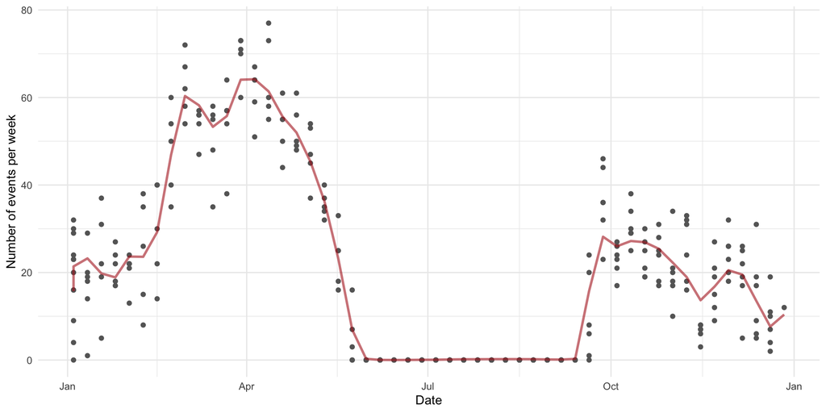

### Geographic Distribution

The derived locations for each trout stocking location is plotted on the map below. Inspection of this map clearly shows that trout waters are concentrated the in Western and Soutwestern parts of the state.

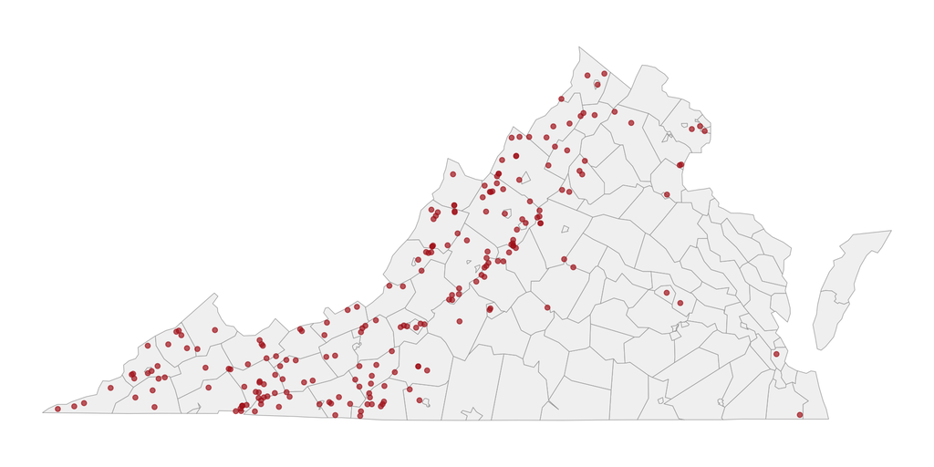

### Fine Structure

The general temporal trends outlined above aren’t the full story. In fact, there are no fewer than eight sub-categories that undergo different levels of trout stocking.

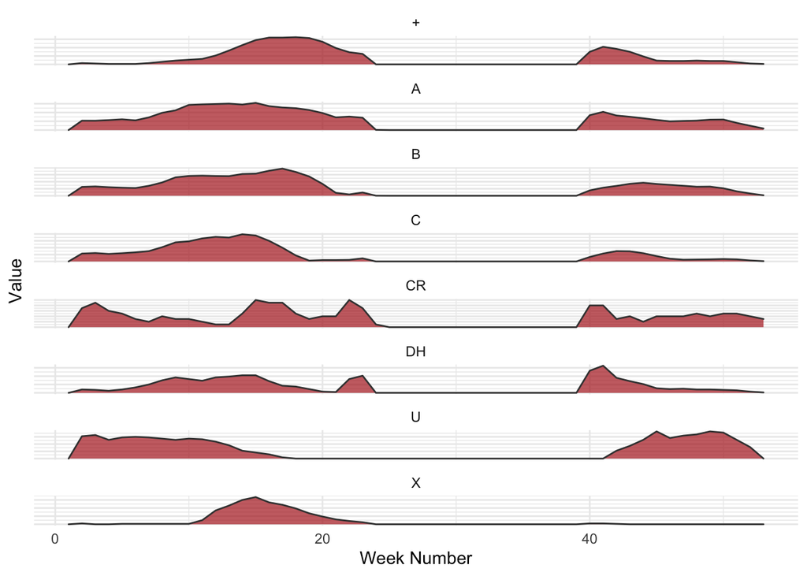

## References

- Virginia Department of Wildlife Recreation [website](https://dwr.virginia.gov/fishing/trout-stocking-schedule/)
- Virginia Department of Wildlife Recreation [interactive map](https://dgif-virginia.maps.arcgis.com/apps/webappviewer/index.html?id=441ed456c8664166bb735b1db6024e48)
- Virginia Department of Environmental Quality [datasets](https://geohub-vadeq.hub.arcgis.com/pages/Water%20Datasets)